# Stacking Order

Technology and the Remaking of Global Interdependence

Luuk Schmitz

Max Planck Institute for the Study of Societies

### The puzzle

Trade volumes persist.  
Supply chains span the globe.  
Capital moves across borders.  
Yet beneath this surface of continuity,  
the *architecture* of interdependence  
is being remade.

### Core concept

## What is a Stack?

stack /stæk/ n.

A vertically integrated system that bundles raw materials, manufacturing, software, and data infrastructure into a singular, non-interoperable architecture.

Following Benjamin Bratton's *The Stack* (2015): sovereignty is no longer only territorial but architectural — layered systems of computation and governance that cut across borders and redefine who controls what.

This book traces how stacks emerged not from grand strategy,  
but from corporate planning routines at the technological frontier.

### The old world

## The Ethereal Economy

The dominant image of successful capitalism carried an *ethereal quality*.

Apple designs in California → Foxconn assembles in Shenzhen → Value captured through IP

Physical assets were liabilities. Manufacturing was modular.  
Suppliers were interchangeable. Interfaces made it all work.

### Modular hierarchy

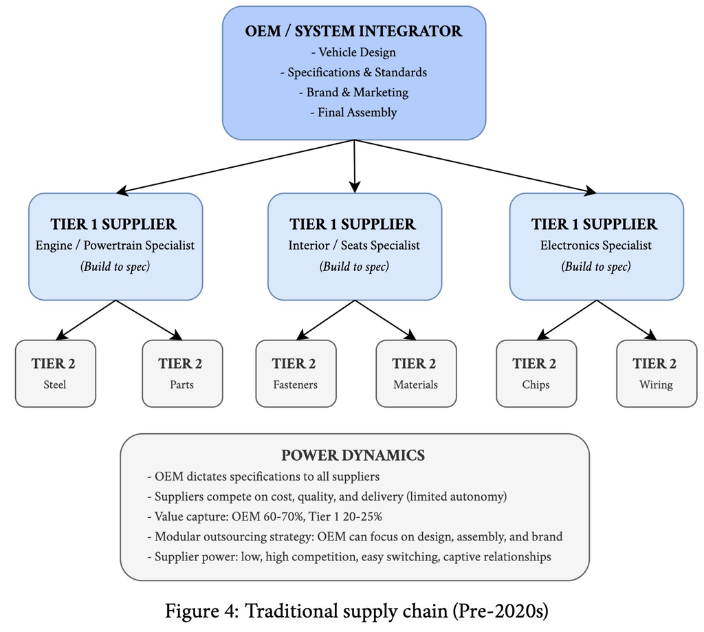

The OEM pyramid: legible interfaces, interchangeable suppliers, value captured at the top.

### The collapse of modularity

## The Physics Strike Back

EVs were supposed to be *more* modular than combustion engines.  
Instead, the empirical evidence showed the opposite.

Battery chemistry cannot be optimized independently from thermal management,  
which cannot be optimized independently from vehicle structure,  
which cannot be optimized independently from software.

To beat the physics, firms had to *beat the market* —  
internalizing coordination that arm's-length  
transactions cannot provide.

### Two responses

## The Bifurcation

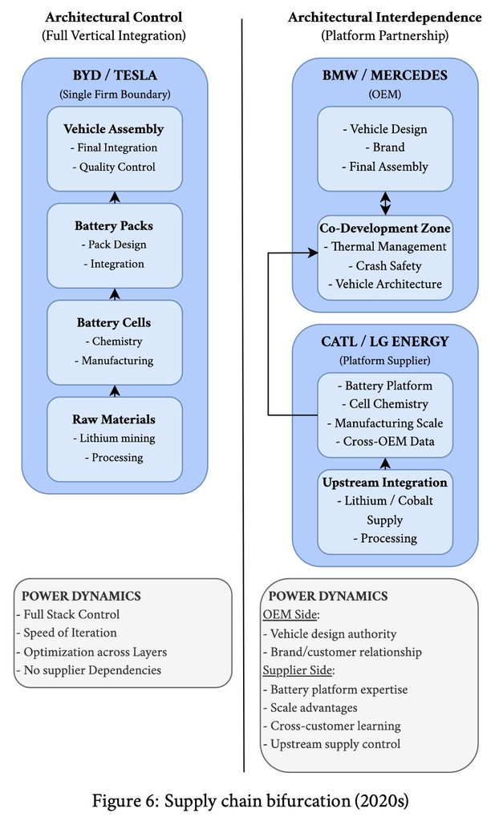

Architectural control (eliminate interfaces entirely) vs. Architectural interdependence (colonize the interface)

### What this looks like

## Two Worlds

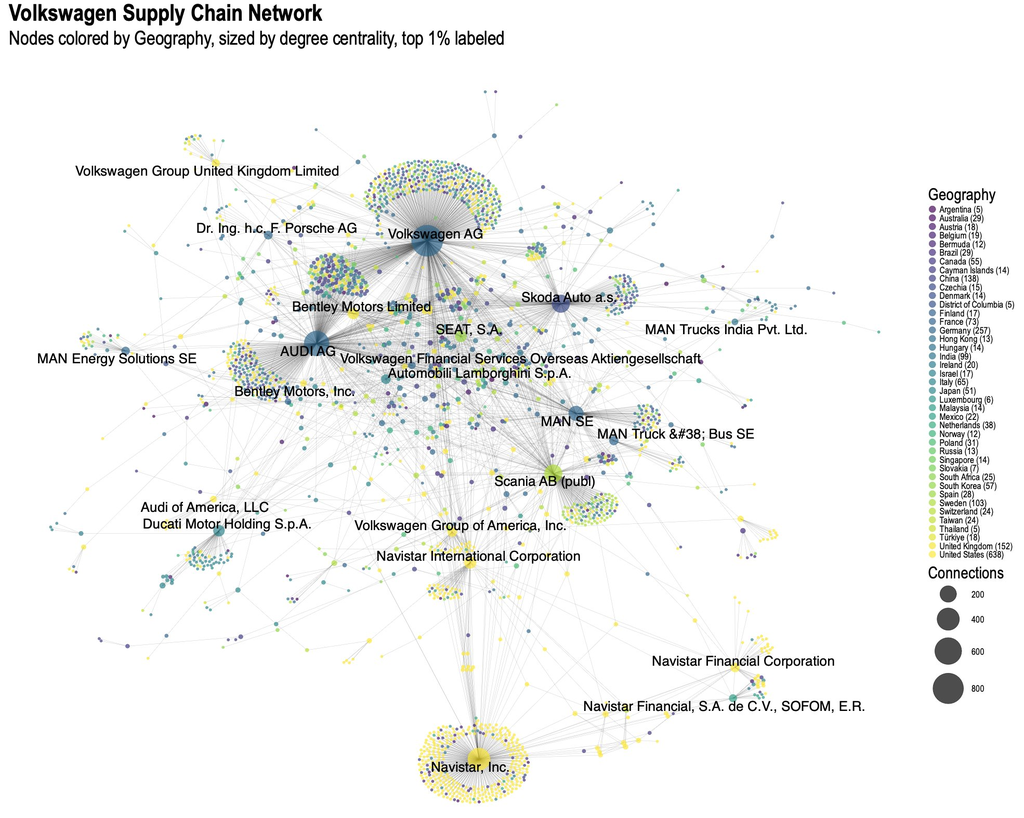

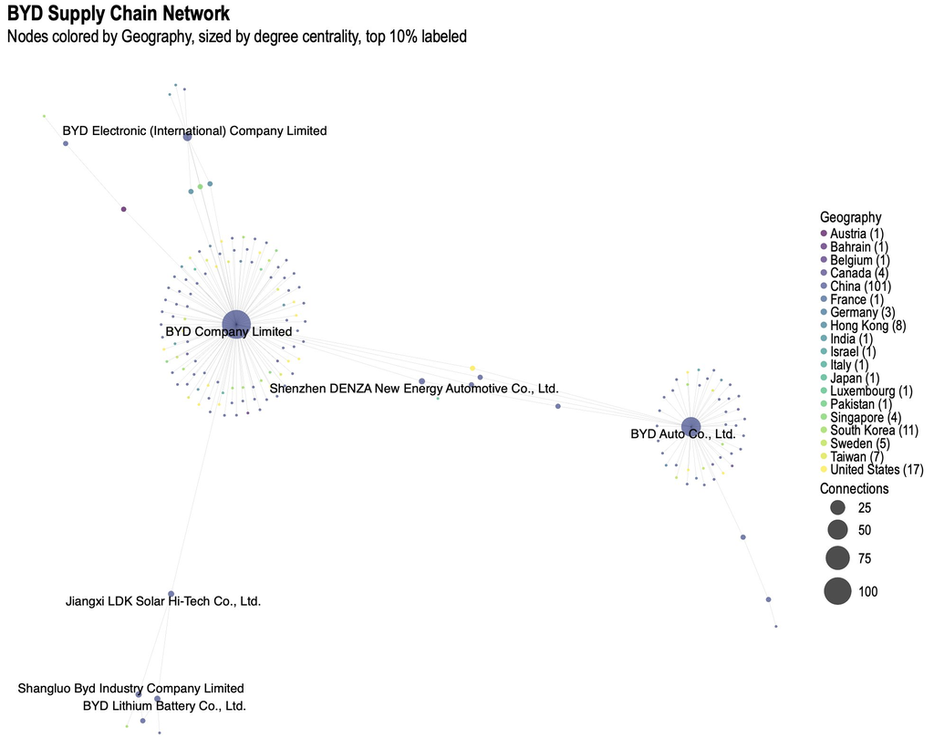

BYD  
~170 entities · China-centric

### The macro-expansion

## From Engineering to Statecraft

Firms solved control in a fragmented world.  
States nationalized the solution.

#### 🇺🇸 Conditional Access

Market-emergent stacks harnessed by the state

Architectural conditionality: reconfigure your infrastructure as the price of admission

G42 stripped $2B of Huawei equipment to access the American AI stack

vs.

#### 🇨🇳 Outward Projection

State-incubated stacks projected abroad

Alignment through accumulated integration: workforce skills, tooling, software ecosystems

$200B+ manufacturing FDI since 2019 — exceeding the Marshall Plan

### The concept

## *Stacked* Interdependence

Not weaponized interdependence — exploiting existing network nodes.  
Not decoupling — severing flows.

Stacked interdependence

A configuration in which control over multiple layers of a vertically integrated production system forecloses the possibility of exit. Power derives not from controlling a single chokepoint, but from the *depth* of integration across the stack.

Key insight: The features designed for profit — lock-in, high switching costs, ecosystem dominance — serve equally well as templates for long-term geopolitical alignment.

### The stakes

## Localization ≠ Sovereignty

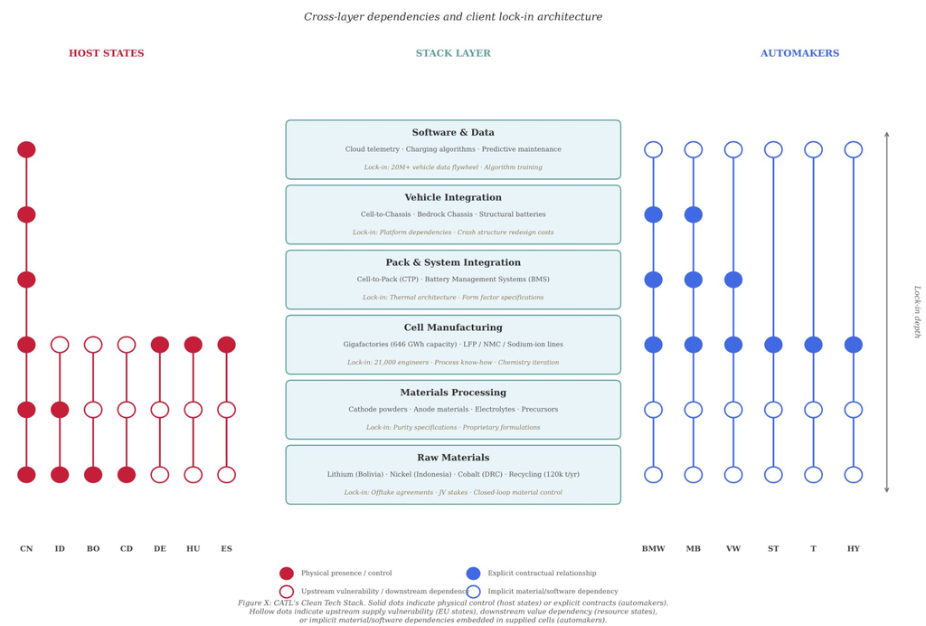

**Resource states** (Bolivia, DRC):  
control extraction, but depend on CATL's downstream processing to realize value.

**European hosts** (Germany, Hungary):  
have gigafactories — but depend on upstream materials beyond their regulatory reach.

Control at one layer does not translate into autonomy across the stack.

### Where stacks collide

## Europe: A Model in Crisis

The October 2024 EV tariff vote — a referendum on Europe's position in the emerging order.

**For tariffs**  
France, Italy, Poland, Netherlands, Baltics, Nordics  
Less integrated into Chinese stacks

**Against tariffs**  
Germany, Hungary, Malta, Slovenia, Slovakia  
Deep stack integration with Chinese architecture

**Abstained**  
Spain, Belgium, Austria, much of Central Europe  
Hedging between stacks

This pattern is illegible through standard EU cleavages — not North/South, not creditor/debtor.  
It becomes legible only through stack exposure.

Defecting from a stack is not like renouncing an ideology.  
It requires ripping out hardware, retraining engineers, and rebuilding systems at costs measured in billions of dollars and years of development time.  
Where Cold War I offered entry through *ideational conversion*,  
Cold War II forecloses exit through *material integration*.

Luuk Schmitz

luuk.schmitz@mpifg.de · Max Planck Institute for the Study of Societies